# Coursera-mcmc-statistics-peer-review-article

Peter Brennan

11/29/2021

## Executive summary/abstract

Proportion tests are standard statistical tools in frequentist statistics to show the asssociation between categorical values. Here they are re-implemented in a bayesian framework.

They are used to answer the research question, ‘Does irradiation (radiation treatment) effect recurrence of or non recurrence of breast cancer’. From the analysis there does appear to be a strong association between irradiation and recurrence of cancer, and non irradiation and non recurrence of cancer.

## Research Question, Does irradiation (radiation treatment) effect recurrence of or non recurrence of breast cancer

We will use Breast cancer data set (a dataset containing categorical data attributes) to try to ascertain the effect of irradiation (radiation treatment) on the recurrence or non-recurrence of breast cancer in the observed data.

## Plan and collect data from a relevant source

The data was chosen from, https://archive.ics.uci.edu/ml/datasets/breast+cancer. The data contains a data file containing the data and a names file containing some meta data about the data. The names of the data attributes are given: 1. Class: no-recurrence-events, recurrence-events 2. age: 10-19, 20-29, 30-39, 40-49, 50-59, 60-69, 70-79, 80-89, 90-99. 3. menopause: lt40, ge40, premeno. 4. tumor-size: 0-4, 5-9, 10-14, 15-19, 20-24, 25-29, 30-34, 35-39, 40-44, 45-49, 50-54, 55-59. 5. inv-nodes: 0-2, 3-5, 6-8, 9-11, 12-14, 15-17, 18-20, 21-23, 24-26, 27-29, 30-32, 33-35, 36-39. 6. node-caps: yes, no. 7. degree.malignant: 1, 2, 3. 8. breast: left, right. 9. breast-quad: left-up, left-low, right-up, right-low, central. 10. irradiation: yes, no.

```
##                  Class   age menopause tumor.size inv.nodes node.caps
## 1 no-recurrence-events 30-39   premeno      30-34       0-2        no
## 2 no-recurrence-events 40-49   premeno      20-24       0-2        no
## 3 no-recurrence-events 40-49   premeno      20-24       0-2        no
## 4 no-recurrence-events 60-69      ge40      15-19       0-2        no
## 5 no-recurrence-events 40-49   premeno        0-4       0-2        no
## 6 no-recurrence-events 60-69      ge40      15-19       0-2        no
##   degree.malignant breast breast.quadrant irradiation
## 1                3   left        left_low          no
## 2                2  right        right_up          no
## 3                2   left        left_low          no
## 4                2  right         left_up          no
## 5                2  right       right_low          no
## 6                2   left        left_low          no
```

Next it is important to perform a summary of the data, to check for missing data and to look at the modal classes for each attribute type

```r
summary(breast.cancer)
```

```
##                   Class        age       menopause     tumor.size inv.nodes
##  no-recurrence-events:201   20-29: 1   ge40   :129   30-34  :60   0-2  :213
##  recurrence-events   : 85   30-39:36   lt40   :  7   25-29  :54   12-14:  3
##                             40-49:90   premeno:150   20-24  :50   15-17:  6
##                             50-59:96                 15-19  :30   24-26:  1
##                             60-69:57                 10-14  :28   3-5  : 36
##                             70-79: 6                 40-44  :22   6-8  : 17
##                                                      (Other):42   9-11 : 10
##  node.caps degree.malignant   breast     breast.quadrant irradiation
##  ?  :  8   1: 71            left :152   ?        :  1    no :218
##  no :222   2:130            right:134   central  : 21    yes: 68
##  yes: 56   3: 85                        left_low :110
##                                         left_up  : 97
##                                         right_low: 24
##                                         right_up : 33
##
```

From the summary it can be seen that there is some missing data from node.caps and breast quadrant data attributes, but apart from that the dataset looks to be of good quality, at least for the purpose of this exercise.

## Explore data

To try to ascertain if any interesting relationships exist in the data a number of data visualization techniques were used, these included: 1. Multiple Correspondence Analysis plot. Here we run multiple correspondence on the data and visualize the results in the hope of identifying strong associations between different attributes. 2. Visualizing the data in the form of stacked bar charts (and stacked bar percent) to look at the relationships/associations between variables. 3. Using contingency tables to look at the proportions between different attributes usign dplyr and table.

# Multiple Correspondence Analysis plot

```r
cats = apply(breast.cancer, 2, function(x) nlevels(as.factor(x)))
cats
```

```
##            Class              age        menopause       tumor.size
##                2                6                3               11
##        inv.nodes        node.caps degree.malignant           breast
##                7                3                3                2
##  breast.quadrant      irradiation
##                6                2
```

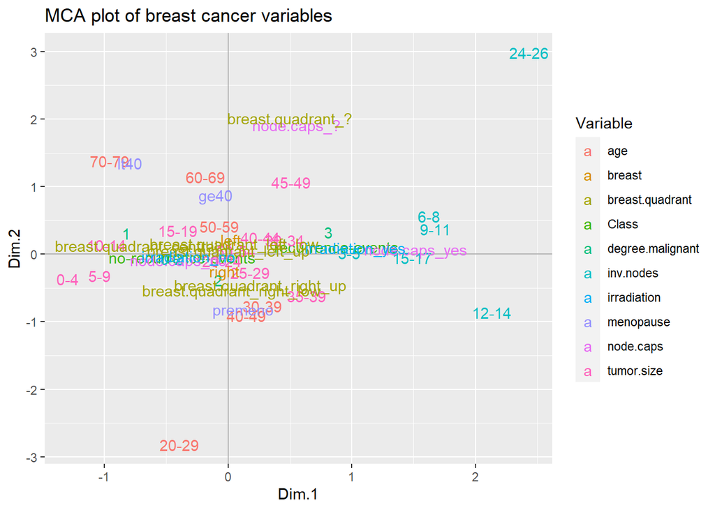

```r
mca1 = MCA(breast.cancer, graph = FALSE)
mca1_vars_df = data.frame(mca1$var$coord, Variable = rep(names(cats),
                                                         cats))
mca1_obs_df = data.frame(mca1$ind$coord)
# plot of variable categories
ggplot(data = mca1_vars_df, aes(x = Dim.1, y = Dim.2, label = rownames(mca1_vars_df))) +
  geom_hline(yintercept = 0, colour = "gray70") + geom_vline(xintercept = 0,
                                                             colour = "gray70") + geom_text(aes(colour = Variable)) + ggtitle("MCA plot of breast cancer variables")
```

From the plot we can see some potentially interesting associations:

1. There appears to be a strong association between irradiation and recurrence events as opposed to a strong association with no irradiation and no-recurrence events.
2. There also appears to be a strong relationship between node-cap-no and Class.

# Visualizing the data in the form of stacked bar charts (and stacked bar percent) to look at the relationships/associations between variables.

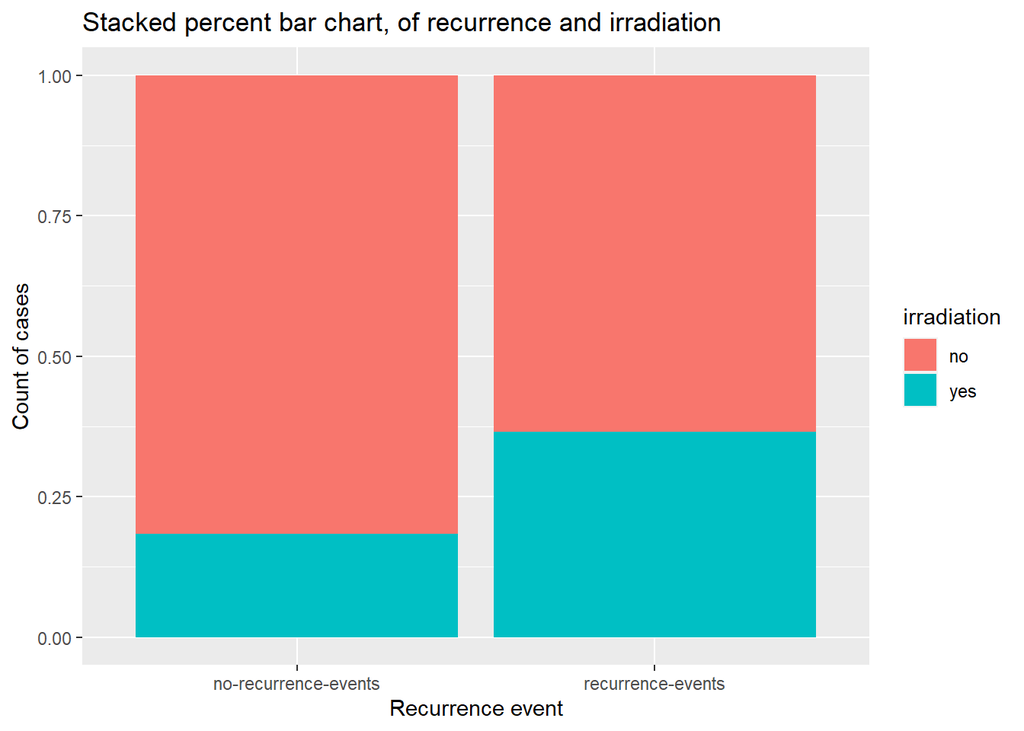

It is clear from the bar chart there is a stronger association between irradiation and recurrence events as opposed to no irradiation and no recurrence events. The same data is shown below in a standard stacked bar chart form.

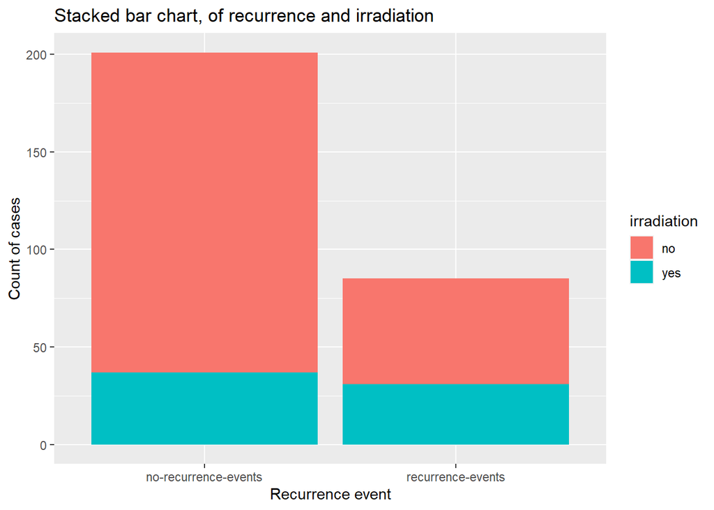

# Contingency tables to look at the proportions between different attributes usign dplyr and table.

The above relationships can also be viewed as contingency tables using either (a) dplyr or the (b) table function. In both cases a strong association is seen between irradiation and recurrence-events

```
## # A tibble: 4 x 3
## # Groups:   irradiation [2]
##   irradiation Class                    n
##   <fct>       <fct>                <int>
## 1 no          no-recurrence-events   164
## 2 no          recurrence-events       54
## 3 yes         no-recurrence-events    37
## 4 yes         recurrence-events       31
```

or as a contingency table

```
##
##       no-recurrence-events recurrence-events
##   no                   164                54
##   yes                   37                31
```

## Postulating a model

We will build a model which aims to show the proportions could not have come from equal proportions (i.e there is no association between them) as opposed to the proportions being unequal and a strong association exists between the groups (irradiation and recurrence events). This is equivalent to a bayesian re-interpretation of the proportions test.

# Describe how the model is well suited to answer your question.

The likelihood model indicates that the observed counts are modeled by a binomial distribution with a probability of p (fraction for each group/total samples) from n trials (items= tot_samples).

# Identify how inference for parameters in the model will provide evidence relating to your question.

The prior on each p is defined as a beta distribution with shape parameters a and b The hyperpriors for each a and b are drawn from imprecise (non informative) gamma distributions. As input, JAGS is supplied with:

1. The observed data (obs)
2. The total number of observed items (n), total samples=164+54+37+31 (see contingency table above)
3. The number of classification groups (nGroups)

# Write the full hierarchical specification of the model.

The model specification is shown below:

```r
modelString1="
model {
   #Likelihood
  for (i in 1:nGroups) {
    obs[i] ~ dbin(p[i],n[i])
    p[i] ~ dbeta(a[i],b[i])
    a[i] ~ dgamma(1,0.01)
    b[i] ~ dgamma(1,0.01)
  }
}
"
```

# Justify your choice of prior distributions.

The beta distribution is used as this is the conjugate prior to the beta distribution, what this means is that if the likelihood function is binomial and the prior distribution, then the posterior distribution is also a beta distribution.

## Fit the model

The model is fit below, as stated in our model specification: 1. The observed data (obs), the observed frequencies of the different groups supplied from the contingency table, (see above). 2. The total number of observed items (n), total samples=164+54+37+31 (see contingency table above) 3. The number of classification groups (nGroups)

```r
tot_samples=164+54+37+31
params<-c("p")

obs <- c(54, 164,37,31)
data.list <- list(obs = obs, n = c(tot_samples, tot_samples,tot_samples,tot_samples), nGroups = 4)
mod1 = jags.model(textConnection(modelString1), data=data.list, inits=NULL, n.chains=3)
update(mod1, 5e3) ## burn in 5000
mod_sim1 = coda.samples(model=mod1,
                        variable.names=params,
                        n.iter=15e3)
mod_csim1 = as.mcmc(do.call(rbind, mod_sim1)) # combined chains
```

## Check the model

A series of checks are run these include: 1. Checking the trace plots of the parameters p[1] to p[4]. 2. Running the Gelman-Rubin diagnostic. 3. Checking the autocorrelation diagnostic. 4. Checking the effective size of the model.

# Checking the trace plots of the parameters p[1] to p[4].

No long term trends are observed in the trace plots. These trace plots look sufficient.

[figure not shown]

# Running the gelman diagnostic.

The Gelman–Rubin convergence diagnostic provides a numerical convergence summary based on multiple chains. The potential scale reudction factor is 1 suggesting convergence.

```
## Potential scale reduction factors:
##
##      Point est. Upper C.I.
## p[1]          1          1
## p[2]          1          1
## p[3]          1          1
## p[4]          1          1
##
## Multivariate psrf
##
## 1
```

# Checking the autocorrelation diagnostic.

```
##                p[1]         p[2]        p[3]         p[4]
## Lag 0   1.000000000  1.000000000  1.00000000  1.000000000
## Lag 1   0.510019942  0.520203507  0.52916331  0.506698370
## Lag 5   0.055295017  0.057561127  0.07575133  0.059994502
## Lag 10 -0.004041405 -0.001109112  0.02158237  0.009821635
## Lag 50 -0.004000933 -0.008613269 -0.01063539 -0.004161139
```

# checking the effective size

```
##     p[1]     p[2]     p[3]     p[4]
## 13522.68 13203.18 12075.50 13286.52
```

##Summary information

```
##
## Iterations = 6001:21000
## Thinning interval = 1
## Number of chains = 3
## Sample size per chain = 15000
##
## 1. Empirical mean and standard deviation for each variable,
##    plus standard error of the mean:
##
##        Mean      SD  Naive SE Time-series SE
## p[1] 0.1908 0.02296 1.082e-04      0.0001975
## p[2] 0.5730 0.02922 1.377e-04      0.0002543
## p[3] 0.1320 0.02001 9.431e-05      0.0001823
## p[4] 0.1109 0.01841 8.677e-05      0.0001598
##
## 2. Quantiles for each variable:
##
##         2.5%     25%    50%    75%  97.5%
## p[1] 0.14781 0.17495 0.1902 0.2059 0.2377
## p[2] 0.51542 0.55341 0.5732 0.5930 0.6292
## p[3] 0.09544 0.11809 0.1311 0.1450 0.1738
## p[4] 0.07764 0.09797 0.1100 0.1228 0.1494
```

# Is the model adequate?

The model diagnostic’s appear to show the model is adequate, however for completion we will retrain the model specifying a less vague conjucate prior beta distribution.

# Fitting the alternative

```r
modelString1A="
model {
   #Likelihood
  for (i in 1:nGroups) {
    obs[i] ~ dbin(p[i],n[i])
    p[i] ~ dbeta(a[i],b[i])
    a[i] ~ dgamma(9,0.5)
    b[i] ~ dgamma(9,0.5)
  }
}
"

tot_samples=164+54+37+31
params<-c("p")

obs <- c(54, 164,37,31)
data.list <- list(obs = obs, n = c(tot_samples, tot_samples,tot_samples,tot_samples), nGroups = 4)
mod1a = jags.model(textConnection(modelString1A), data=data.list, inits=NULL, n.chains=3)
update(mod1a, 5e3) ## burn in 5000
mod_sim1a = coda.samples(model=mod1a,
                        variable.names=params,
                        n.iter=15e3)
mod_csim1a = as.mcmc(do.call(rbind, mod_sim1a)) # combined chains
```

# Next test the diagnostics for the model

[figure not shown]

```
## Potential scale reduction factors:
##
##      Point est. Upper C.I.
## p[1]          1          1
## p[2]          1          1
## p[3]          1          1
## p[4]          1          1
##
## Multivariate psrf
##
## 1
```

[output not shown]

```r
effectiveSize(mod_sim1a)
```

```
##     p[1]     p[2]     p[3]     p[4]
## 24209.39 23868.92 21370.42 23541.54
```

The summary information is shown below, it is approximately the same as the fist iteration

[output not shown]

# Provide relevant posterior summaries.

The summary information is listed below (detailing the posterior distributions), we can see that collectively, the fractions of 1/4, 1/4,1/4,1/4 (0.25,0.25,0.25,0.25) do not fall within these ranges.

```r
summary(mod_sim1a)
```

```
##
## Iterations = 6001:21000
## Thinning interval = 1
## Number of chains = 3
## Sample size per chain = 15000
##
## 1. Empirical mean and standard deviation for each variable,
##    plus standard error of the mean:
##
##        Mean      SD  Naive SE Time-series SE
## p[1] 0.2004 0.02331 1.099e-04      0.0001499
## p[2] 0.5706 0.02893 1.364e-04      0.0001874
## p[3] 0.1424 0.02056 9.691e-05      0.0001410
## p[4] 0.1218 0.01911 9.008e-05      0.0001246
##
## 2. Quantiles for each variable:
##
##         2.5%    25%    50%    75%  97.5%
## p[1] 0.15717 0.1843 0.1995 0.2158 0.2482
## p[2] 0.51436 0.5507 0.5705 0.5903 0.6273
## p[3] 0.10447 0.1282 0.1416 0.1557 0.1854
## p[4] 0.08683 0.1086 0.1209 0.1343 0.1614
```

# Interpret the model results in the context of the problem and come to a conclusion

There appears to be a strong association between irradiation and recurrence of cancer, and non irradiation and non recurrence of cancer.